# DATA 550 Lab 3 (group lab) - Communication visualizations

### Question 4.2

rubric={accuracy:2}

#### Python

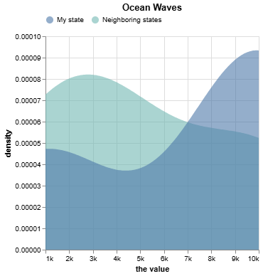

```python
# YOUR ANSWER HERE
alt.Chart(state).transform_density(
    'the value',
    as_=['the value', 'density'],
    groupby=['where']
).mark_area(opacity=0.6).encode(
    x=alt.X(
        'the value:Q',
        scale=alt.Scale(domain=[1000, 10000]),
        axis=alt.Axis(
            values=list(range(1000, 10001, 1000)),
            labelExpr="datum.value / 1000 + 'k'"
        )
    ),
    y=alt.Y('density:Q',stack=None),
    color=alt.Color(
        'where:N',
        scale=alt.Scale(
            domain=['My state', 'Neighboring states'],
            range=['#4C78A8', '#72B7B2']
        ),
        legend=alt.Legend(title=None,orient='top'),

    )
).properties(title=alt.TitleParams(text='Ocean Waves'))
```

### Question 4.3

rubric={accuracy:2}

#### R

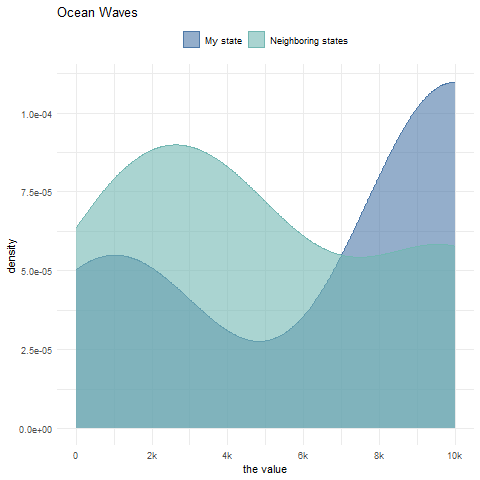

```python
%%R
# YOUR ANSWER HERE
library(scales)

state=read.csv('state-comparison.csv')
ggplot(state, aes(x = `the.value`, fill = where, colour = where)) +
  geom_density(alpha = 0.6) +
  scale_x_continuous(
    limits = c(0, 10000),
    breaks = seq(0, 10000, by = 2000),
    labels = function(x) {ifelse(x != 0, paste0(x / 1000, "k"), "0")}
  ) +
  scale_y_continuous(
    limits = c(0e+00, 1.1e-04),
    breaks = seq(0e+00, 1.0e-04, by = 1.0e-04/4),
  ) +
  scale_fill_manual(
    values = c("My state" = "#4C78A8", "Neighboring states" = "#72B7B2")
  ) +
  scale_colour_manual(
    values = c("My state" = "#4C78A8", "Neighboring states" = "#72B7B2")
  ) +
  labs(
    x = "the value",
    y = "density",
    title = "Ocean Waves"
  ) +
  theme_minimal() +
  theme(
    legend.title = element_blank(),
    legend.position = "top"
  )
```

### Question 4.4 (Optional)

rubric={viz:1}

#### Python

Improve my Altair plot. Chose the best type of plot to accurately reveal what the data looks like. Design the plot to be an effective plot for communication purposes, this includes proper figure size, axis/figure titles, font sizes, colors, etc.

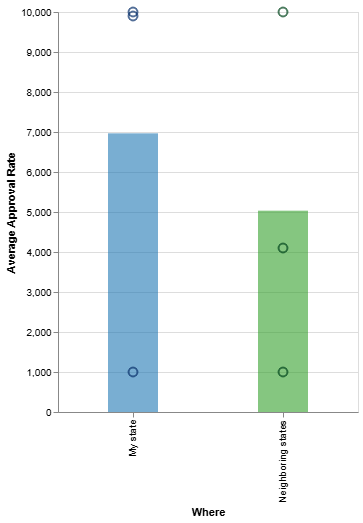

```python
# YOUR ANSWER HERE
bars = (
    alt.Chart(state)
    .transform_aggregate(
        mean_value='mean(the value)',
        groupby=['where']
    )
    .mark_bar(opacity=0.6,width=50)
    .encode(
        x=alt.X('where:N', title='Where'),
        y=alt.Y('mean_value:Q', title='Average Approval Rate'),
        fill=alt.Fill(
            'where:N',
            scale=alt.Scale(domain=['My state', 'Neighboring states'],
                            range=['#1f78b4', '#33a02c']),
        legend=None
        )
    )
)

points = (
    alt.Chart(state)
    .mark_point(size=80)
    .encode(
        x='where:N',
        y='the value:Q',
        color=alt.Color(
            'where:N',
            scale=alt.Scale(domain=['My state', 'Neighboring states'],
                            range=['#08306b', '#00441b']),
        )
    )
)

(bars + points).properties(
    width=300,
    height=400
)
```

### Question 4.5 (Optional)

rubric={viz:1}

#### R

Improve my ggplot plot. Chose the best type of plot to accurately reveal what the data looks like. Design the plot to be an effective plot for communication purposes, this includes proper figure size, axis/figure titles, font sizes, colors, etc.

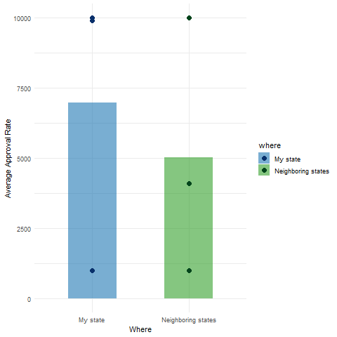

```python
%%R
# YOUR ANSWER HERE
ggplot(state, aes(x = where, y = the.value,fill=where)) +
  stat_summary(fun = mean, geom = "col", width = 0.5, alpha = 0.6) +
  geom_point(aes(colour=where),size = 3) +
  scale_fill_manual(values = c(
    "My state" = "#1f78b4",
    "Neighboring states" = "#33a02c"
  )) +
  scale_colour_manual(values = c(
    "My state" = "#08306b",
    "Neighboring states" = "#00441b"
  )) +
  theme_minimal() +
  labs(x='Where',y='Average Approval Rate')
```

### Question 5 (Optional)

rubric={viz:0.5,reasoning:0.5}

#### R or Python

Pick a existing ggplot or Altair chart and improve at least 3 different communication related aspects of this plot that we have discussed in lectures. In addition, show your proficiency in reading the documentation and looking for help online, by finding one communication related parameter that we have not discussed in lectures and use it to improve the visuals of the plot (it is also ok to use an option that we haven’t discussed of a parameter that we have discussed).

1. Paste in the code of the existing plot you picked and run it so that we can see what the original looked like. Include the URL to the original plot as a comment in the code cell.
   - You can take any plot you want! As long as you can find the source code and paste it here (and it is not copyright protected). There are suggestions for [ggplot here](https://www.r-graph-gallery.com/) and [Altair here](https://altair-viz.github.io/gallery/index.html).
2. In a new cell, make your modifications and plot the improved chart.
3. Briefly describe the changes you made and why they make this plot more suitable for communication. Explicitly mention which new parameter/option you picked that we have not discussed before and why you picked it.

## Q5 first try

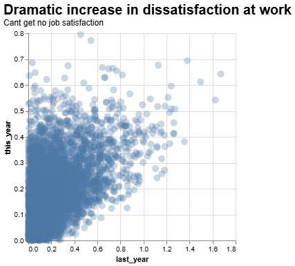

```python
# %%R
alt.Chart(job_satisfaction).mark_point(size=100, opacity=0.3, filled=True).encode(
    x = alt.X('last_year'),
    y = alt.Y('this_year'),
).properties(
    title=alt.Title(
        "Dramatic increase in dissatisfaction at work",
        subtitle="Cant get no job satisfaction",
        anchor='start',
        fontSize=20
    )
)
```

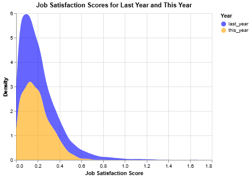

```python
alt.Chart(job_satisfaction).transform_fold(
    ['last_year', 'this_year'],
    as_ = ['year', 'satisfaction']
).transform_density(
    'satisfaction',
    as_=['satisfaction', 'density'],
    groupby=['year']
).mark_area(opacity=0.6).encode(
    x=alt.X('satisfaction:Q', title='Job Satisfaction Score'),
    y=alt.Y('density:Q', title='Density'),
    color=alt.Color('year:N', title='Year', scale=alt.Scale(domain=['last_year', 'this_year'], range=['blue', 'orange']))
).properties(
    title='Job Satisfaction Scores for Last Year and This Year',
    width=400,
    height=300
)
```

I chose the plot from question 1. I made it into an overlapping density plots so we can better visualize the distribution of the job satisfaction scores over two years. This allows the viewer to immediatly see the results without having to think too much about how the previous scatter plot relates the two variables. The previous plot made it confusing and some might think that there was an increase in job satisfaction.